# ZOO955 - Autocorrelation

Hilary Dugan

3/13/2018

## Tobler’s first law of geography

*“Everything is related to everything else, but near things are more related than distant things”.*

Often we can use autocorrelation as prediction (ie. interpolation [next week]).

- But it is also an important component of mechanistic modeling.
- Can ecology beat the null model of autocorrelation?

### References

- http://rspatial.org/analysis/rst/3-spauto.html
- http://www.bias-project.org.uk/ASDARcourse/unit6_slides.pdf
- http://www.stat.purdue.edu/~bacraig/SCS/Spatial%20Correlation%20new.doc
- https://dynamicecology.wordpress.com/2013/10/02/autocorrelation-friend-or-foe/comment-page-1/

### What is autocorrelation?

**Autocorrelation** refers to the correlation of a time series with its own past and future values

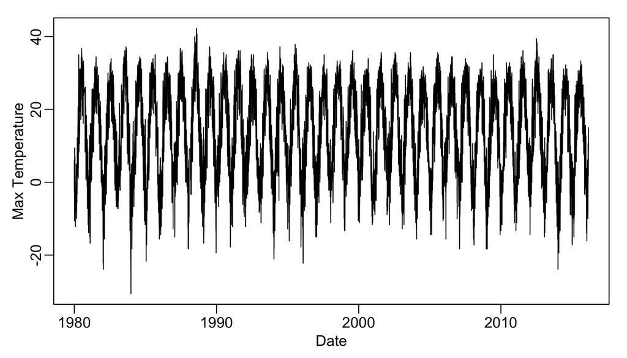

```r
library(dplyr)
par(mar=c(3,3,1,1),mgp=c(1.5,0.5,0))

met = read.csv('Data/arbMet.csv',stringsAsFactors = F)
met = met %>% mutate(DATE = as.Date(DATE))
met$tmax = approx(met$DATE,met$TMAX, xout = met$DATE, method="linear")[[2]] # Fill in gaps linearly
met[is.na(met$PRCP),]$PRCP = 0 # replace NA precip events with zero

plot(met$DATE,met$TMAX,type='l',ylab='Max Temperature', xlab = 'Date')
```

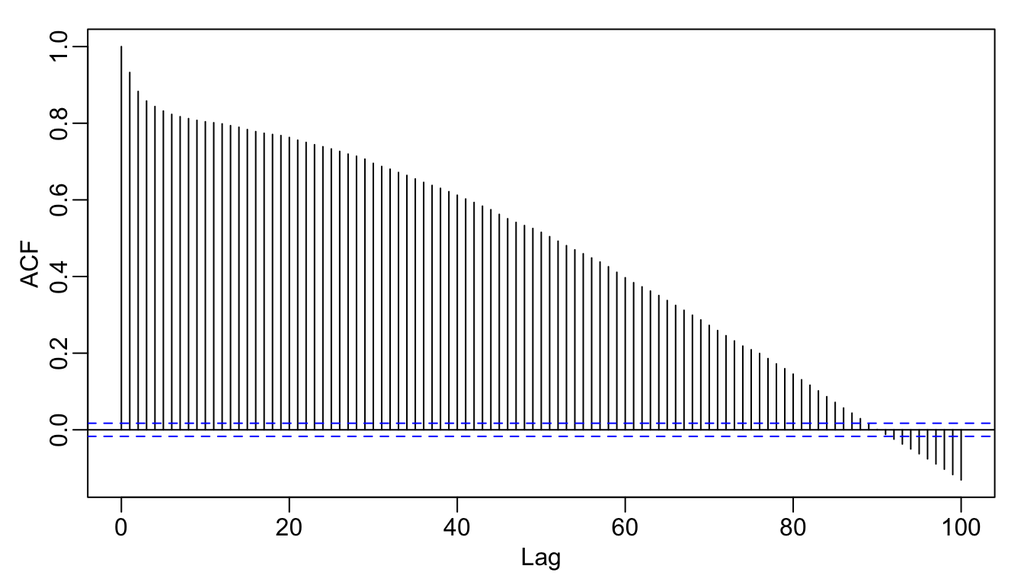

```r
acf(met$tmax,lag.max = 100) # auto-correlation function
```

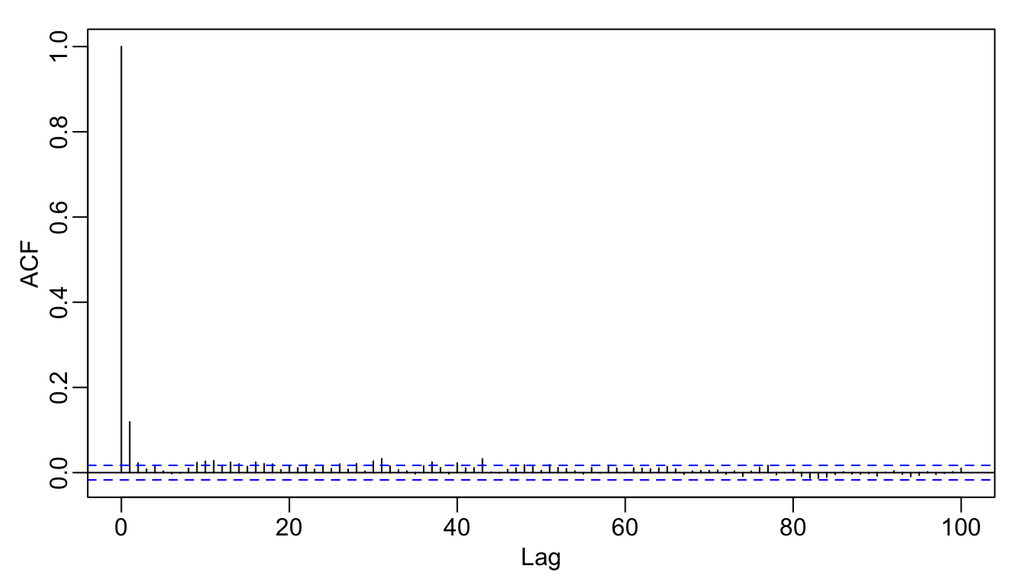

```r
acf(met$PRCP,lag.max = 100)
```

**Spatial autocorrelation** measures the correlation of a variable with itself through space.

- Spatial autocorrelation can be positive or negative.
- Positive spatial autocorrelation occurs when similar values occur near one another.
- Negative spatial autocorrelation occurs when dissimilar values occur near one another.

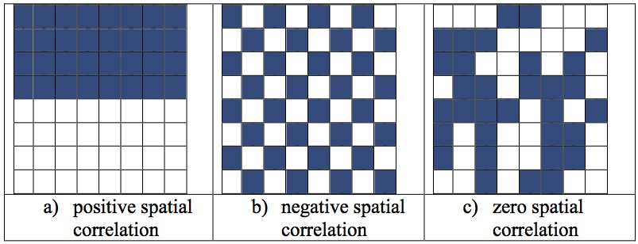

https://docs.aurin.org.au/wp-content/uploads/sites/2/2014/09/Spatial_Autocorrelation.jpg

### Why should we care about autocorrelation?

- Autocorrelation invalidates most traditional statistical inference tests
- If SA exists, then the results of standard statistical inference tests may be incorrect
  - Correlation coefficients appear to be bigger than they really are
  - They are more likely to be found “statistically significant” (p-value inflation)
- Must use spatial statistical inference tests

## How do we detect spatial autocorrelation?

Basically turning autocorrelation (repeated correlations) to two dimensions.

To accomplish this, a **spatial weights matrix** is computed.

### Spatial Matrix

- `spdep` package
- The first step is to determine the sets of neighbours for each observation, the second to assign weights to each neighbour relationship

### Weight Matrix

To assess spatial autocorrelation

1. What is meant by two observations being close together
   - i.e., a distance measure must be determined.
2. These distances are presented in weight matrix, which defines the relationships between locations where measurements were made.

The weight matrix can be specified in many ways: * The weight for any two different locations is a constant. * All observations within a specified distance have a fixed weight. * K nearest neighbors have a fixed weight, and all others are zero. * Weight is proportional to inverse distance, inverse distance squared, or inverse distance up to a specified distance.

Other weight matrices are possible. The weight matrix is often row-standardized, i.e., all the weights in a row sum to one. Note that the actual values in the weight matrix are up to the researcher.

### Moran’s I

Moran’s I measures spatial autocorrelation based on both feature locations and feature values simultaneously. Given a set of features and an associated attribute, it evaluates whether the pattern expressed is clustered, dispersed, or random.

Moran’s I is calculated as a ratio of the product of the variable of interest and its spatial lag, with the cross-product of the variable of interest, and adjusted for the spatial weights used:

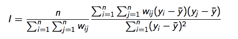

where `yi` is the i-th observation, `¯y` is the mean of the variable of interest, and `wij` is the spatial weight of the link between `i` and `j`.

Centering on the mean is equivalent to asserting that the correct model has a constant mean, and that any remaining patterning after centering is caused by the spatial relationships encoded in the spatial weights

## Compute spatial autocorrelation examples: Percent water in Wisconsin counties

```r
# Load data
perWater = read.csv('../Zoo955_WeeklyAssignments/Week6_WIwater_NLCD.csv',stringsAsFactors = F)
# Counties data
library(rgdal)
counties = readOGR('../Lecture6_Overlays/Data/County_Boundaries_24K/County_Boundaries_24K.shp',layer='County_Boundaries_24K')
# Add water to dataframe
counties$water = perWater$perWater
```

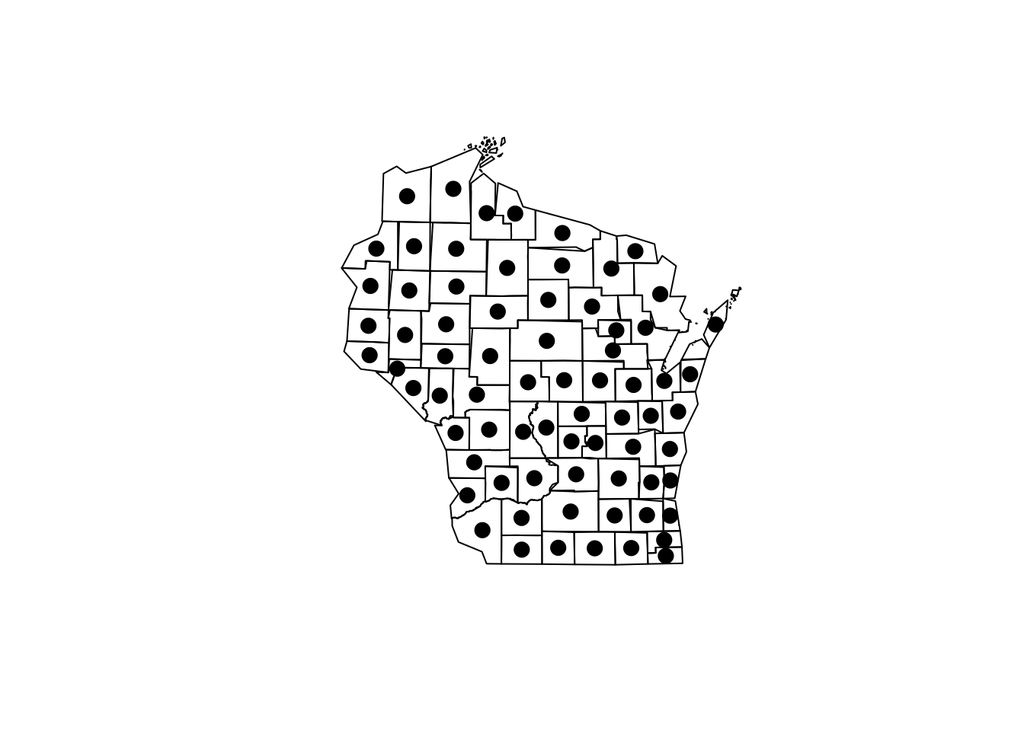

```r
# Because we're going to keep plotting counties, simplify data
library(rgeos)
cSimp <- gSimplify(counties, tol=5000, topologyPreserve=TRUE)
plot(cSimp)
# Get centroid coordinates and plot
xy <- coordinates(counties)
points(xy, cex=2, pch=20)
```